# Estimates of molecular convergence reveal multiple genes with adaptive variation across teleost fishes - Report

### Phenotype plots

The plot shows the distribution of phenotype keyword terms and the frequency of affected phenotype terms from ZFIN. Panel on the left shows the effect of genetic perturbation on the convergent genes. Panel on the right shows the number of unique affected structures that show a phenotype after genetic perturbation. The data shows that mutations in the convergent genes can affect several phenotypes and structures, with a majority of the effects showing a decrease or reduction in affected structures or processes, while a few shows an increase.

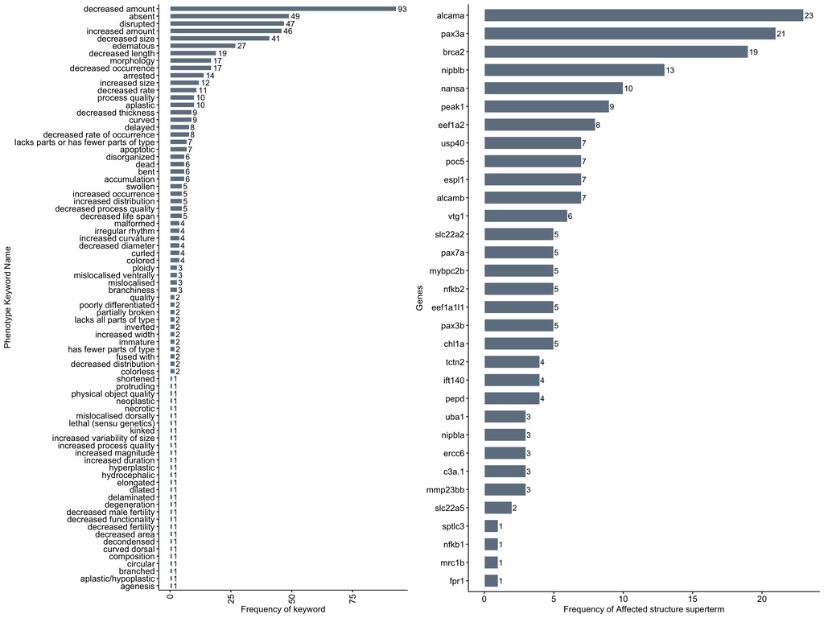

```r
ph_dat<-pheno_conv %>% summarise(n = n(),.by = c(`Phenotype Keyword Name`)) %>% mutate(`Phenotype Keyword Name`=reorder(`Phenotype Keyword Name`,n))
g1<-ggpubr::ggbarplot(ph_dat, y = "Phenotype Keyword Name", x = "n",
                  x.text.angle = 90,
                  fill = "#708090",
                  color = "white",
                  xlab = "Frequency of keyword")+
    geom_text(aes(label = n), hjust = -0.2)


read_tsv("./Datasets/DatasetS0_csv_files/phenoGeneCleanData_fish_2023.05.07.tsv")->pheno #Download from ZFIN
#ph_c<-pheno %>% filter(`Gene Symbol` %in% pheno_conv$`Gene name`)
ph_c<-pheno %>% filter(`Gene Symbol` %in% pheno_conv$`Gene name`) %>% dplyr::select(`Gene Symbol`,`Affected Structure or Process 1 superterm ID`) %>%
  na.omit() %>% distinct(`Affected Structure or Process 1 superterm ID`,.keep_all = T) %>%
  summarise(n = n(),.by = c(`Gene Symbol`)) %>%
  mutate(type = "convergent") %>% arrange(desc(n))


make_pheno_terms_dist<-function(d){
  pheno %>% filter(`Gene Symbol` == d) %>% distinct(`Affected Structure or Process 1 superterm ID`,.keep_all = T) %>%
  summarise(n = n(),.by = c(`Affected Structure or Process 1 superterm Name`,`Publication ID`)) %>% mutate(Gene_symbol = d)
}

purrr::map(ph_c$`Gene Symbol`,make_pheno_terms_dist) %>% bind_rows() %>%
  dplyr::select(Gene_symbol,`Affected Structure or Process 1 superterm Name`) %>%
  summarise(n = n(),.by = c(Gene_symbol))->ph_c

ph_c$Gene_symbol<-factor(ph_c$Gene_symbol,levels = c(ph_c %>% arrange((n)) %>% pull(Gene_symbol)))
g2<-ggpubr::ggbarplot(ph_c,y = "Gene_symbol",
                      x = "n",
                      fill = "#708090",
                      color = "white",
                      x.text.angle = 0,
                      xlab = "Frequency of Affected structure superterm",
                      ylab = "Genes")+
  geom_text(aes(label = n), hjust = -0.1)

ggpubr::ggarrange(g1,g2)
```

The chord diagram shows that for some genes the perturbation phenotypes occur across multiple tissue systems (e.g. alcama, pax3a). The length of the grey bars correspond to the frequency values in the bar plot.

```r
library(circlize)
pheno_terms<-read_csv("./Datasets/DatasetS0_csv_files/Pheno_terms_table_revised.csv")
pheno_terms %>% summarise(n = n(),.by = c(`Gene Symbol`,tissue_system))
```

| Gene Symbol | tissue_system | n |
| --- | --- | --- |
| alcama | Nervous | 11 |
| alcama | Skeletal | 6 |
| alcama | Circulatory | 5 |
| alcama | Whole organism | 1 |
| alcama | Digestive | 1 |
| alcamb | Nervous | 6 |
| alcamb | Embryo | 1 |
| arid1b | Whole organism | 2 |
| brca2 | Whole organism | 1 |
| brca2 | Nervous | 6 |

[output cut: 96 more lines]

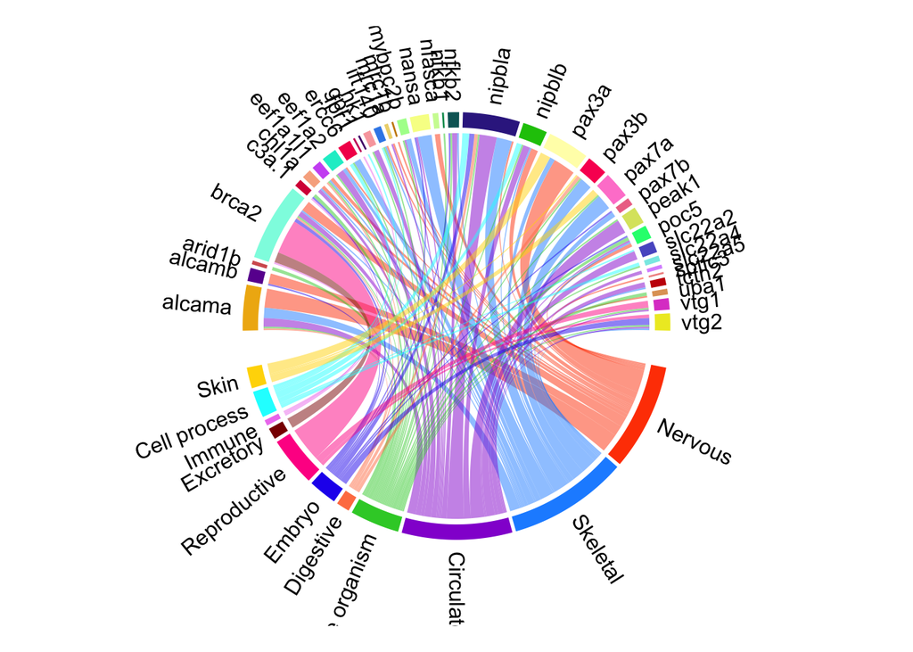

```r
pheno_terms_wide<-pheno_terms %>% summarise(n = n(),.by = c(`Gene Symbol`,tissue_system)) %>%
  pivot_wider(names_from = `Gene Symbol`, values_from = n)
pheno_terms_wide[is.na(pheno_terms_wide)]=0

df_matrix <- pheno_terms_wide %>%
  select(-tissue_system) %>%  # Remove the Gene_symbol column
  as.matrix()

rownames(df_matrix)<-pheno_terms_wide$tissue_system

tissue_colors_vibrant <- c(
  "Nervous" = "#FF4500",      # Orange Red
  "Skeletal" = "#1E90FF",     # Dodger Blue
  "Circulatory" = "#9400D3",  # Dark Violet
  "Whole organism" = "#32CD32", # Lime Green
  "Digestive" = "#FF7F50",    # Coral
  "Embryo"= "#2611EE",        # Dark Navy
  "Skin" = "#FFD700",         # Gold
  "Excretory" = "#8B0000",    # Dark Red
  "Reproductive" = "#FF1493", # Deep Pink
  "Cell process" = "#00FFFF", # Cyan
  "Immune" = "#EE82EE"     # Violet
)


chordDiagram(df_matrix,
             annotationTrack = "grid",
             preAllocateTracks = 1,grid.col = tissue_colors_vibrant)

# Add labels for each tissue
circos.trackPlotRegion(track.index = 1, panel.fun = function(x, y) {
  tissue = CELL_META$sector.index
  circos.text(CELL_META$xcenter, CELL_META$ylim[1] + .1, tissue,
              facing = "clockwise", niceFacing = TRUE, adj = c(0, 0.5))
}, bg.border = NA)
```

### Comparing the distributions

```r
#Load all the data
tau_dat_all<-readRDS("./RDS/tau_dat_all.rds")
read_csv("./Datasets/DatasetS0_csv_files/Danio_biomart.csv")->Danio_biomart
danio_conv<-read.csv("./Datasets/DatasetS0_csv_files/Danio_rerio_convergent_genes.csv")
read_tsv("./Datasets/DatasetS0_csv_files/phenoGeneCleanData_fish_2023.05.07.tsv")->pheno
#Takes a long time
#pheno2 %>% mutate(Gene_symbol=str_extract(rem_str, paste(Danio_biomart$`Gene name`, collapse = "|")))->pheno2
#pheno2 %>% dplyr::rename("Gene Symbol"="Gene_symbol")->pheno2
#pheno2 %>% saveRDS("./RDS/pheno_with_clean_gene_symbol.rds")
readRDS("./RDS/pheno_with_clean_gene_symbol.rds")->pheno2

rbind(pheno %>% dplyr::select(c(`Gene Symbol`, `Affected Structure or Process 1 superterm ID`, `Publication ID`,`Affected Structure or Process 1 superterm Name`)),
      pheno2 %>%  dplyr::select(c(`Gene Symbol`, `Affected Structure or Process 1 superterm ID`, `Publication ID`,`Affected Structure or Process 1 superterm Name`))) %>%
    group_by(`Gene Symbol`) %>% na.omit() %>%
    mutate(uniq_affected_terms=length(unique(`Affected Structure or Process 1 superterm ID`)),
           uniq_pubs=length(unique(`Publication ID`))) %>% distinct(`Gene Symbol`, .keep_all = T)->pheno_summary

inner_join(
Danio_biomart %>% dplyr::select(`Gene stable ID`,`Gene name`,`Gene description`) %>% dplyr::rename("Gene.ID"=`Gene stable ID`,"Gene Symbol"=`Gene name`),
pheno_summary,by = "Gene Symbol") %>% na.omit() %>% distinct(Gene.ID,.keep_all = T)->pheno_summary

#inner_join(pheno_summary,
#estimated_ts_conv_Danio_tau_conv_all %>% dplyr::select(Gene.ID, conv), by = "Gene.ID")->pheno_summary

inner_join(pheno_summary,
           orth_list %>% dplyr::select(Orthogroup,orths) %>% dplyr::rename("Gene.ID"=orths),
           by="Gene.ID") %>%
  dplyr::select(Gene.ID,Orthogroup,everything())->pheno_summary

#Summarise the average number of affected phenotypic terms by Orthogroup
#because each orthogroup has different genes with reporting of phenotypes
#Look at the above pheno_summary data and compare with the Danio_biomart df.

rbind(
  pheno_summary %>% summarise(n=mean(uniq_affected_terms),.by = c("Orthogroup")) %>% filter(Orthogroup %in% non_spuroius_conv$Orthogroup) %>% mutate(state="Convergent"),
  pheno_summary %>% summarise(n=mean(uniq_affected_terms),.by = c("Orthogroup")) %>% filter(!Orthogroup %in% non_spuroius_conv$Orthogroup) %>% mutate(state="Non-convergent"))->pheno_test_dat

ksboot(x=pheno_test_dat %>% filter(state=="Convergent") %>% pull(n),
       y=pheno_test_dat %>% filter(!state=="Convergent") %>% pull(n),alternative = "greater",nboots = 5000)->ks_test_res

ks_test_res
```

```
## $ksboot.pvalue
## [1] 0.0296
##
## $nboots
## [1] 5000
```

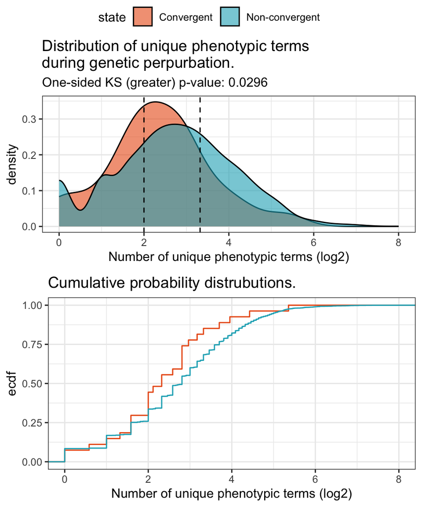

```r
q1<-quantile(log2(pheno_test_dat$n),.33)
q2<-quantile(log2(pheno_test_dat$n),.66)

pheno_test_dat %>%
  ggplot(aes(x=log2(n), fill=state))+
  geom_density(alpha=0.6)+
  scale_fill_manual(values = c("#EA5B15","#1AAEC0"))+
  theme_bw()+
  geom_vline(xintercept = q1, linetype="dashed")+
  geom_vline(xintercept = q2, linetype="dashed")+
  xlab("Number of unique phenotypic terms (log2)")+
  labs(title = "Distribution of unique phenotypic terms\nduring genetic perpurbation.",
       subtitle = paste0("One-sided KS (greater) p-value: ",ks_test_res$ksboot.pvalue))->dist_mutant_phenotypes

pheno_test_dat %>%
  ggplot(aes(x=log2(n), color = state))+
  stat_ecdf()+
  scale_color_manual(values = c("#EA5B15","#1AAEC0"))+
  theme_bw()+
  xlab("Number of unique phenotypic terms (log2)")+
  labs(title = "Cumulative probability distrubutions.")->ecdf_mutant_phenotypes

ggarrange(dist_mutant_phenotypes,ecdf_mutant_phenotypes, ncol = 1, common.legend = T)
```

```r
conv_sp<-read_csv("./Datasets/DatasetS0_csv_files/Convergence_in_species.csv")
fish_data<-read.csv("./Datasets/DatasetS0_csv_files/Fish_data.csv")
danio_conv<-read.csv("./Datasets/DatasetS0_csv_files/Danio_rerio_convergent_genes.csv")
tax_info_conv<-left_join(conv_sp,fish_data, by = "Species")
orth_list<-readRDS("./RDS/large_fish_tree_all_orders.rds")
orth_list<-orth_list %>% mutate(orths =  str_remove(orth_list$orths,"..$"))
orth_list<-orth_list %>% mutate(Order = if_else(Order == "Carangaria", "Carangiformes", Order)) #Fix order name
orth_list<-left_join(orth_list %>% dplyr::rename(Species = sp),fish_data %>% dplyr::select(c(Species,Family)),by = "Species")
non_spuroius_conv<-read_csv("Datasets/DatasetS0_csv_files/Non_spurious_conv.csv")
seq_stat<-read_tsv("./Datasets/DatasetS0_csv_files/seq_stats.tsv") #use the seqkit toolkit (https://bioinf.shenwei.me/seqkit/) to obtain this
combined_arity <-readRDS("./RDS/combined_arity.rds")
#All convergent genes in all species and orders
left_join(tax_info_conv,danio_conv %>% dplyr::select(Orthogroup,Gene.name,Gene.description),by = "Orthogroup") %>% distinct(Protein_id, .keep_all = T)->tax_info_conv
```

## Relationships between copy number and convergence

### OCN ~ number of genes

There was no significant relationship between OCN and number of genes in Orthogroup

```r
library(ggpubr)
#Relationship between OCN and number of genes in Orthogroup
seq_stat<-read_tsv("./Datasets/DatasetS0_csv_files/seq_stats.tsv") #use the seqkit toolkit (https://bioinf.shenwei.me/seqkit/) to obtain this
combined_arity<-combined_arity %>% filter(Orthogroup %in% non_spuroius_conv$Orthogroup)
cor_dat<-left_join(combined_arity %>% summarise(mean_OCN = log10(mean(OCNany2spe)),.by = "Orthogroup") %>% drop_na(),seq_stat,by = "Orthogroup")
```

#### Remove potential outliers

```r
cor_dat %>% filter(mean_OCN < 1)->cor_dat_no_out
#cor_dat %>% slice_sample(n = 50)->cor_dat_no_out
cor.test(cor_dat_no_out$mean_OCN, log10(cor_dat_no_out$num_seqs), method = "pearson")->p

ocn_gene_cor_plot_no_out<-ggpubr::ggscatter(cor_dat_no_out,
                                            x = "mean_OCN", y = "num_seqs",
                                            add = "reg.line",
                                            color = "grey70",
                                            add.params = list(color = "red3"))+
  annotate("text",
           x=0.75, y=max(cor_dat$num_seqs),
           label = paste0("R = ",round(p$estimate,2),", ","p = ",round(p$p.value,2)))+
  xlab("Mean log10(OCN) value")+
  ylab("Average number of genes in orthgroup")+
  font("xlab", size = 10)+
  font("ylab", size = 10)

p
```

```
##
##  Pearson's product-moment correlation
##
## data:  cor_dat_no_out$mean_OCN and log10(cor_dat_no_out$num_seqs)
## t = 1.6663, df = 82, p-value = 0.09947
## alternative hypothesis: true correlation is not equal to 0
## 95 percent confidence interval:
##  -0.0347696  0.3806024
## sample estimates:
##       cor
## 0.1809746
```

### OCN ~ length of genes

#### Remove potential outliers

```r
#cor_dat %>% filter(mean_OCN < 1)->cor_dat_no_out
cor_dat %>% slice_sample(n = 50)->cor_dat_no_out

cor.test(log10(cor_dat_no_out$mean_OCN), log10(cor_dat_no_out$avg_len), method = "pearson")->p

ocn_len_cor_plot_no_out<-ggpubr::ggscatter(cor_dat_no_out,
                                            x = "mean_OCN", y = "avg_len",
                                            add = "reg.line",
                                            color = "grey70",
                                            add.params = list(color = "red3"))+
  annotate("text",
           x=0.75, y=max(cor_dat$avg_len),
           label = paste0("R = ",round(p$estimate,2),", ","p = ",round(p$p.value,2)))+
  xlab("Mean log10(OCN) value")+
  ylab("Average length of genes (bp) in orthgroup")+
  font("xlab", size = 10)+
  font("ylab", size = 10)

p
```

```
##
##  Pearson's product-moment correlation
##
## data:  log10(cor_dat_no_out$mean_OCN) and log10(cor_dat_no_out$avg_len)
## t = -2.0659, df = 48, p-value = 0.04426
## alternative hypothesis: true correlation is not equal to 0
## 95 percent confidence interval:
##  -0.522540011 -0.008047024
## sample estimates:
##        cor
## -0.2857547
```

### Correlation plots

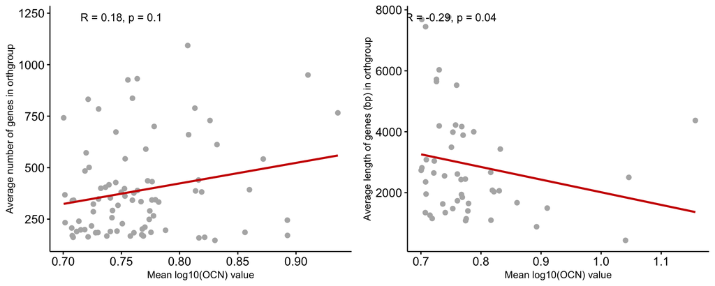

```r
gridExtra::grid.arrange(ocn_gene_cor_plot_no_out,ocn_len_cor_plot_no_out,ncol=2)
```

## Non-global distribution of copy number

We repeated the test for difference in distributions for the clades with at least one species harbouring a convergent substitution and found that not all clades show a consistent pattern of high copy number in the convergent sets. At the Order level 86% (31 out of 36), and at the level of Family 83% (61 out of 73) showed evidence for higher copy number in convergent genes. Therefore, while a majority of clades do show evidence of higher copy number of convergent genes, this is not general over all teleosts.

### Distribution of convergent gene copy number per Family

```r
tax_info_conv %>% dplyr::count(Orthogroup,Family) %>% kbl() %>%  kable_styling() %>%
  scroll_box(width = "350px", height = "400px")
```

| Orthogroup | Family | n |
| --- | --- | --- |
| OG0000107 | Cichlidae | 1 |
| OG0000107 | Gymnotidae | 1 |
| OG0000107 | Sciaenidae | 1 |
| OG0000135 | Epinephelidae | 1 |
| OG0000135 | Labridae | 1 |
| OG0000135 | Pomacentridae | 1 |
| OG0000170 | Apogonidae | 1 |
| OG0000170 | Batrachoididae | 1 |
| OG0000170 | Echeneidae | 1 |
| OG0000195 | Cyclopteridae | 1 |
| OG0000195 | Serranidae | 1 |
| OG0000195 | Tetraodontidae | 3 |
| OG0000233 | Albulidae | 1 |
| OG0000233 | Osmeridae | 1 |
| OG0000233 | Salmonidae | 3 |
| OG0000236 | Chaetodontidae | 1 |
| OG0000236 | Cichlidae | 5 |
| OG0000236 | Gobiesocidae | 1 |
| OG0000236 | Scatophagidae | 1 |
| OG0000236 | Sparidae | 1 |
| OG0000240 | Denticipitidae | 1 |
| OG0000240 | Sparidae | 2 |
| OG0000240 | Syngnathidae | 1 |
| OG0000243 | Cyprinidae | 2 |
| OG0000243 | Gobiesocidae | 1 |
| OG0000295 | Ambassidae | 1 |
| OG0000295 | Mugilidae | 1 |
| OG0000295 | Serranidae | 1 |
| OG0000348 | Blenniidae | 1 |
| OG0000348 | Echeneidae | 1 |

[output cut: 291 more lines]

```r
tax_info_conv %>% dplyr::count(Orthogroup,Family) %>%
  mutate(Family=reorder(Family, -n)) %>%
  ggplot(aes(x=n, y=Family))+
  facet_wrap(~Orthogroup, scales="free_y")+
  geom_col(fill="#4DBBD5FF",linewidth=0.1)+
  geom_text(aes(label=n, x=n+0.8), size=3)+
  labs(x="Number of convergent gene copies")+
  theme_bw()+
  theme(axis.text.y = element_text(face = "italic"),
        axis.text.x = element_text(hjust = 1, vjust = 0.5),
        strip.background = element_rect(fill="grey95"))->family_conv_dist_orth

tax_info_conv %>% dplyr::count(Family) %>%
    mutate(Family=reorder(Family, n)) %>%
    ggplot(aes(x=n, y=Family))+
    geom_col(fill="#4DBBD5FF",linewidth=0.1)+
    geom_text(aes(label=n, x=n+2), size=3)+
    labs(x="Number of convergent gene copies")+
    theme_minimal()+
    theme(axis.text.y = element_text(face = "italic"),
          axis.text.x = element_text(hjust = 1, vjust = 0.5),
          strip.background = element_rect(fill="grey95"))->family_conv_dist
```

### Distribution of convergent gene copy number per Order

```r
tax_info_conv %>% dplyr::count(Orthogroup,Order) %>% kbl() %>%  kable_styling() %>%
  scroll_box(width = "350px", height = "400px")
```

| Orthogroup | Order | n |
| --- | --- | --- |
| OG0000107 | Acanthuriformes | 1 |
| OG0000107 | Cichliformes | 1 |
| OG0000107 | Gymnotiformes | 1 |
| OG0000135 | Labriformes | 1 |
| OG0000135 | Ovalentaria | 1 |
| OG0000135 | Perciformes | 1 |
| OG0000170 | Batrachoidiformes | 1 |
| OG0000170 | Carangiformes | 1 |
| OG0000170 | Kurtiformes | 1 |
| OG0000195 | Perciformes | 2 |
| OG0000195 | Tetraodontiformes | 3 |
| OG0000233 | Albuliformes | 1 |
| OG0000233 | Osmeriformes | 1 |
| OG0000233 | Salmoniformes | 3 |
| OG0000236 | Acanthuriformes | 3 |
| OG0000236 | Cichliformes | 5 |
| OG0000236 | Gobiesociformes | 1 |
| OG0000240 | Acanthuriformes | 2 |
| OG0000240 | Clupeiformes | 1 |
| OG0000240 | Syngnathiformes | 1 |
| OG0000243 | Cypriniformes | 2 |
| OG0000243 | Gobiesociformes | 1 |
| OG0000295 | Mugiliformes | 1 |
| OG0000295 | Ovalentaria | 1 |
| OG0000295 | Perciformes | 1 |
| OG0000348 | Blenniiformes | 1 |
| OG0000348 | Carangiformes | 1 |
| OG0000348 | Pleuronectiformes | 1 |
| OG0000385 | Beloniformes | 1 |
| OG0000385 | Centrarchiformes | 1 |

[output cut: 228 more lines]

```r
tax_info_conv %>% dplyr::count(Orthogroup,Order) %>%
  mutate(Order=reorder(Order, -n)) %>%
  ggplot(aes(x=n, y=Order))+
  facet_wrap(~Orthogroup, scales="free_y")+
  geom_col(fill="#4DBBD5FF",linewidth=0.1)+
  geom_text(aes(label=n, x=n+1), size=3)+
  labs(x="Number of convergent gene copies")+
  theme_bw()+
  theme(axis.text.y = element_text(face = "italic"),
        axis.text.x = element_text(hjust = 1, vjust = 0.5),
        strip.background = element_rect(fill="grey95"))->order_conv_dist_orth

tax_info_conv %>% dplyr::count(Order) %>%
    mutate(Order=reorder(Order, n)) %>%
    ggplot(aes(x=n, y=Order))+
    geom_text(aes(label=n, x=n+2), size=3)+
    geom_col(fill="#4DBBD5FF",linewidth=0.1)+
    labs(x="Number of gene copies")+
    theme_minimal()+
    theme(axis.text.y = element_text(face = "italic"),
          axis.text.x = element_text(hjust = 1, vjust = 0.5),
          strip.background = element_rect(fill="grey95"))->order_conv_dist
```

### Plot of Order and Family

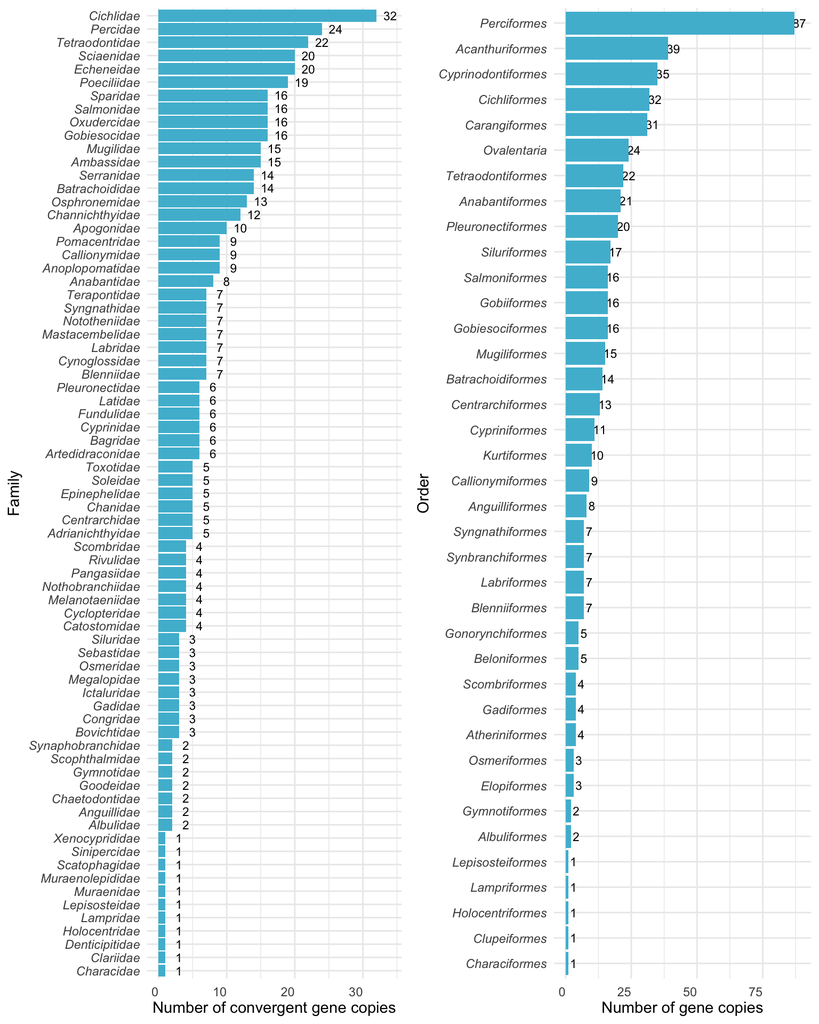

```r
ggarrange(family_conv_dist,order_conv_dist)
```

### Test for difference in distributions

```r
conv_seq_clades<-orth_list %>% filter(Family %in% tax_info_conv$Family) %>%
  filter(Orthogroup %in% tax_info_conv$Orthogroup) %>%
  dplyr::count(Orthogroup,Family,name = "num_seqs") %>% drop_na()

bg_seq_clades<-orth_list %>% filter(Family %in% tax_info_conv$Family) %>%
  filter(!Orthogroup %in% tax_info_conv$Orthogroup) %>%
  dplyr::count(Orthogroup,Family,name = "num_seqs") %>% drop_na()

boot_ks_clades<-function(clade){
  ks_data_frame <- function() {

    num<-conv_seq_clades %>% pull(num_seqs) %>% length()

    tibble(n.estimated = conv_seq_clades %>% pull(num_seqs),
           n.sampled = bg_seq_clades %>% slice_sample(n = num) %>% pull(num_seqs))
    }

  conv_seq_clades %>% filter(Family==clade)->conv_seq_clades
  bg_seq_clades %>% filter(Family==clade)->bg_seq_clades

  map(1:100, function(x) ks_data_frame())->ls

  run_ks<-function(d){
    kldtools::ksboot(x = d$n.sampled,
                     y = d$n.estimated,
                     alternative = "greater",nboots = 2000)$ksboot.pvalue
    }
  map(ls,run_ks) %>% return()
}

family_list<-conv_seq_clades %>% distinct(Family) %>% pull(Family)

purrr::map(family_list, ~
             tibble(adj.p.values = p.adjust(p = boot_ks_clades(clade=.x),method = "BH")) %>%
             mutate(Family=.x)) %>% list_rbind()->per_family_num_seq_ks_test


per_family_num_seq_ks_test %>% saveRDS("./RDS/per_family_num_seq_ks_test.rds")
```

```r
per_family_num_seq_ks_test<-readRDS("./RDS/per_family_num_seq_ks_test.rds")
per_order_num_seq_ks_test<-readRDS("./RDS/per_order_num_seq_ks_test.rds")

per_order_num_seq_ks_test %>% summarise(mean_adj_p=mean(adj.p.values),.by = "Order") %>% dplyr::count(mean_adj_p < 0.05) %>% kbl() %>%  kable_styling() %>%
  scroll_box(width = "200px", height = "200px")
```

| mean_adj_p < 0.05 | n |
| --- | --- |
| FALSE | 5 |
| TRUE | 31 |

```r
per_family_num_seq_ks_test %>% summarise(mean_adj_p=mean(adj.p.values),.by = "Family") %>% dplyr::count(mean_adj_p < 0.05) %>% kbl() %>%  kable_styling() %>%
  scroll_box(width = "200px", height = "200px")
```

| mean_adj_p < 0.05 | n |
| --- | --- |
| FALSE | 12 |
| TRUE | 61 |

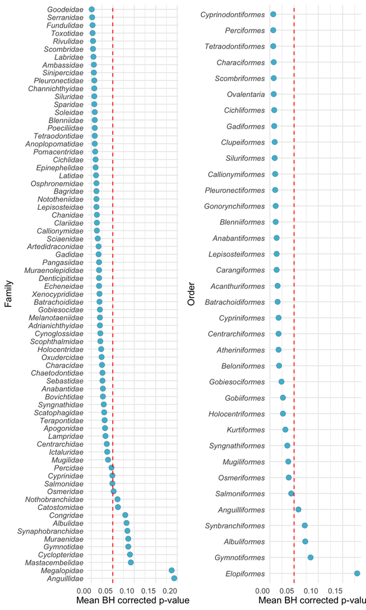

```r
ggarrange(
  per_family_num_seq_ks_test %>% summarise(mean_adj_p=mean(adj.p.values),.by = "Family") %>%
  mutate(Family=reorder(Family, -mean_adj_p)) %>%
  ggplot(aes(x=round(mean_adj_p,3), y=Family))+
  geom_point(fill="#4DBBD5FF",stroke=0.1,shape=21, size=3)+
  geom_vline(xintercept = 0.05, linetype="dashed", color="red")+
    labs(x="Mean BH corrected p-value")+
    theme_minimal()+
    theme(axis.text.y = element_text(face = "italic"),
          axis.text.x = element_text(hjust = 1, vjust = 0.5),
          strip.background = element_rect(fill="grey95")),

per_order_num_seq_ks_test %>% summarise(mean_adj_p=mean(adj.p.values),.by = "Order") %>%
  mutate(Order=reorder(Order, -mean_adj_p)) %>%
  ggplot(aes(x=round(mean_adj_p,3), y=Order))+
  geom_point(fill="#4DBBD5FF",stroke=0.1,shape=21, size=3)+
  geom_vline(xintercept = 0.05, linetype="dashed", color="red")+
    labs(x="Mean BH corrected p-value")+
    theme_minimal()+
    theme(axis.text.y = element_text(face = "italic"),
          axis.text.x = element_text(hjust = 1, vjust = 0.5),
          strip.background = element_rect(fill="grey95")),
ncol = 2
)
```

## Expression of convegent genes in species with convergent substitutions

Here I use data from Bgee to check for expression of the genes with convergent substitutions in the species where the substitution occurred. To enable robust comparisons across conditions, experiments, and data types, I use the expression scores computed by Bgee. These scores provide a normalised measure of a gene’s expression across multiple anatomical and developmental conditions. In this framework, higher expression scores indicate stronger expression in a given anatomical entity and developmental stage. This approach offers a consistent and quantitative assessment of the spatial and temporal breadth of gene expression within each species. Using this metric I show that the convergent genes have a wide spatial and temporal breadth, being expressed across multiple tissues and different developmental stages.

```r
#These are the files obtained from the Bgee API
#See here on how to donwload them: https://www.bgee.org/doc-api/

files <- list.files(path = "./Bgee_jsons", pattern = "*.json", full.names = TRUE)
bgee_json<-function(file) {
  library(jsonlite)

  jd <- fromJSON(file, flatten = TRUE)

  calls_df <- jd$data$calls

  tibble(
      anatEntity_name = calls_df$condition.anatEntity.name,
      devStage_id     = calls_df$condition.devStage.id,
      devStage_name   = calls_df$condition.devStage.name,
      sex             = calls_df$condition.sex,
      expressionScore = as.numeric(calls_df$expressionScore.expressionScore),
      confidence             = calls_df$expressionScore.expressionScoreConfidence,
      gene_id   = jd$data$gene$geneId,
      gene_name = jd$data$gene$name,
      species   = jd$data$gene$species$name) %>% return()
}

purrr::map(files, bgee_json) %>% list_rbind() %>%
   left_join(tax_info_conv, by=c("gene_id"="Protein_id")) %>%
   filter(!devStage_name %in% c("sexually immature stage",
                                "organogenesis stage",
                                "neurula stage", "zygote stage") &
            !anatEntity_name %in% c("sexually immature organism", "animal zygote")) %>%
   mutate(gene_name= case_when(gene_name == "NANS" ~ "nansa",
                               gene_name == "" ~ "asic1a",
                               .default = gene_name))->bgee_exp
```

### Astatotilapia calliptera

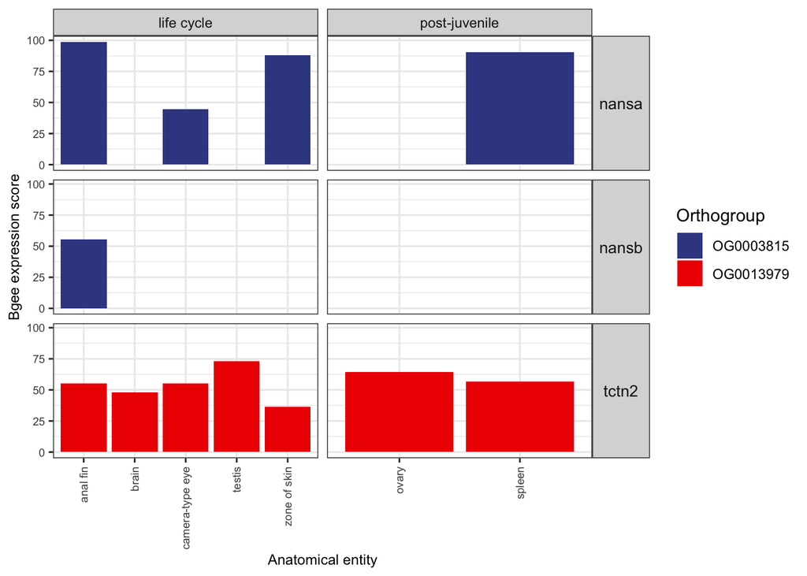

```r
bgee_exp %>% filter(Species=="Astatotilapia_calliptera") %>%
   group_by(anatEntity_name,devStage_name,gene_id) %>%
   mutate(expressionScore=mean(expressionScore)) %>%
   distinct(anatEntity_name,devStage_name, .keep_all = TRUE) %>%
   mutate(anatEntity_name=reorder(anatEntity_name,-expressionScore)) %>%
   ggplot(aes(x=anatEntity_name,y=expressionScore,group = Species))+
   facet_grid(rows=vars(gene_name), cols = vars(devStage_name), scales = "free_x")+
   geom_bar(aes(fill=Orthogroup),
            stat = "identity",
            position = "stack",
            alpha = 1)+
   ggsci::scale_fill_aaas()+
   labs(y="Bgee expression score",
        x="Anatomical entity")+
   theme_bw()+
   theme(axis.text.x = element_text(angle = 90,size=7, hjust = 1, vjust = 0.5),
         axis.text.y.left  = element_text(size = 7),
         plot.title = element_text(face="italic", size=11),
         axis.title = element_text(size=9),
        strip.text.y.right =  element_text(angle = 360, size = 10),
        strip.background  =  element_rect(fill = "grey85"))
```

### Neolamprologus brichardi

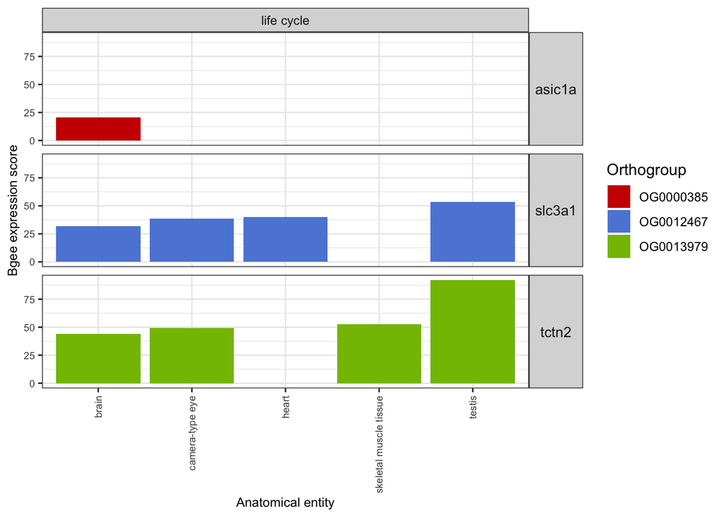

```r
bgee_exp %>% filter(Species=="Neolamprologus_brichardi") %>%
   group_by(anatEntity_name,devStage_name,gene_id) %>%
   mutate(expressionScore=mean(expressionScore)) %>%
   distinct(anatEntity_name,devStage_name, .keep_all = TRUE) %>%
   mutate(anatEntity_name=reorder(anatEntity_name,-expressionScore)) %>%
   ggplot(aes(x=anatEntity_name,y=expressionScore,group = Species))+
   facet_grid(rows=vars(gene_name), cols = vars(devStage_name), scales = "free_x")+
   geom_bar(aes(fill=Orthogroup),
            stat = "identity",
            position = "stack",
            alpha = 1)+
   ggsci::scale_fill_startrek()+
   labs(y="Bgee expression score",
        x="Anatomical entity")+
   theme_bw()+
   theme(axis.text.x = element_text(angle = 90,size=7, hjust = 1, vjust = 0.5),
         axis.text.y.left  = element_text(size = 7),
         plot.title = element_text(face="italic", size=11),
         axis.title = element_text(size=9),
        strip.text.y.right =  element_text(angle = 360, size = 10),
        strip.background  =  element_rect(fill = "grey85"))
```

### Salmo salar

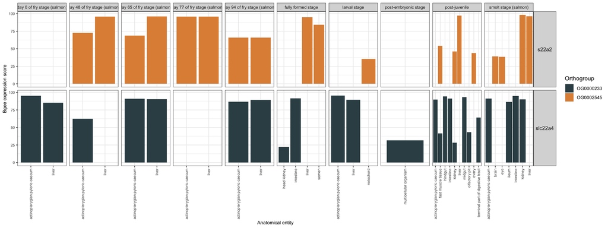

```r
bgee_exp %>% filter(Species=="Salmo_salar") %>%
   group_by(anatEntity_name,devStage_name,gene_id) %>%
   mutate(expressionScore=mean(expressionScore)) %>%
   distinct(anatEntity_name,devStage_name, .keep_all = TRUE) %>%
   mutate(anatEntity_name=reorder(anatEntity_name,-expressionScore)) %>%
   ggplot(aes(x=anatEntity_name,y=expressionScore,group = Species))+
   facet_grid(rows=vars(gene_name), cols = vars(devStage_name), scales = "free_x")+
   geom_bar(aes(fill=Orthogroup),
            stat = "identity",
            position = "stack",
            alpha = 1)+
   ggsci::scale_fill_jama()+
   labs(y="Bgee expression score",
        x="Anatomical entity")+
   theme_bw()+
   theme(axis.text.x = element_text(angle = 90,size=7, hjust = 1, vjust = 0.5),
         axis.text.y.left  = element_text(size = 7),
         plot.title = element_text(face="italic", size=11),
         axis.title = element_text(size=9),
        strip.text.y.right =  element_text(angle = 360, size = 10),
        strip.text.x.top =  element_text(size = 8),
        strip.background  =  element_rect(fill = "grey85"))
```

## FUBAR analysis

To detect evidence for purifying selection across the the sites we used the Fast Unconstrained Bayesian Approximation (FUBAR) method from the hyphy set of models. This Bayesian approach infers synonymous and non-synonymous substitutions rates on a per-site basis for a given coding alignment and phylogeny while being robust to false positives and model misspecification. We found that over 80% of the convergent sites showed evidence of purifying selection across all the convergent genes, while only 1% showed evidence for diversifying selection. Around 19% of the sites did not provide a reliable estimate for either selection regime.

```r
library(jsonlite)
non_spuroius_conv$Orthogroup
#Parse HyPhy output
list.files("./Datasets/DatasetS14_SLAC_analysis/FUBAR/") %>%
  str_remove_all("_cds_hammer.fa.FUBAR.json")->og

fubar_json_parse<- function(orth) {
  f<-read_json(paste0("./Datasets/DatasetS14_SLAC_analysis/FUBAR/",orth,"_cds_hammer.fa.FUBAR.json"),
               simplifyVector = )
  headers <- map_chr(f$MLE$headers,1)
  rows <- f$MLE$content$`0`
  rows <- purrr::modify(rows, ~ modify(.x, ~ if (is.null(.x)) 0 else .x))
  sites <- f$`data partitions`$`0`$coverage

  map(.x = rows,
      ~as_tibble(setNames(as.list(.x), c(headers,"q1","q2")))) %>% list_rbind() %>%
    mutate(sites=seq(1:length(sites[[1]])),
           Orthogroup=orth) %>%
    dplyr::select(Orthogroup,sites, everything()) %>%
    return()
}

purrr::map(og,fubar_json_parse) %>% list_rbind()->fubar_res

#Get the csubst site data
score_table<-readRDS("./RDS/sub_Matix_score_output.rds") %>% distinct(pdb_id)

get_csubst_site<-function(ids){
#Prepare csusbt site output
files<-list.files(path = paste0("./Datasets/DatasetS6_Non_spurious_convergence"),
                  pattern = paste0(ids,".tsv"),
                              full.names = TRUE, recursive = TRUE)

list.files(path = paste0("./Datasets/DatasetS6_Non_spurious_convergence"),
           pattern = paste0(ids,".tsv"),
           full.names = TRUE, recursive = TRUE) %>%
  str_extract_all("OG[0-9]*")->og
#read in file
dat<-read_tsv(files[1]) %>%
  dplyr::select(codon_site_alignment, OCNany2spe) %>%
  mutate((Orthogroup=og[[1]])) %>%
  return()
}

purrr::map(score_table$pdb_id, get_csubst_site) %>% list_rbind() %>%
  dplyr::rename("Orthogroup"=`(Orthogroup = og[[1]])`)->csubst_site_res

csubst_site_res %>% filter(OCNany2spe > 0.1)->csubst_site_res_filtered

left_join(csubst_site_res_filtered,fubar_res,
          by=c("codon_site_alignment"="sites",
               "Orthogroup"="Orthogroup")) %>%
  dplyr::select(Orthogroup,codon_site_alignment,OCNany2spe, everything())->sites_selection
```

```r
sites_selection<-readRDS("./RDS/sites_selection.rds")
sites_selection %>% mutate(selection=case_when(`Prob[alpha>beta]` > 0.9 ~ "purifying",
                                            `Prob[alpha<beta]` > 0.9 ~"diversifying",
                                            .default = "low evidence")) %>%
  dplyr::count(selection) %>% mutate(n.per=((n/sum(n))*100) %>% round()) %>%
  mutate(selection=reorder(selection,-n.per)) %>%
  ggplot(aes(x=selection, y=n.per))+
  geom_col(aes(fill=selection))+
  geom_text(aes(label = n.per, y=n.per+1))+
  scale_fill_manual(values=c("#4F868C","grey80","#D92B04"))+
  labs(y="Percentage of sites", x="Selection")+
  theme_bw()->site_freq

sites_selection %>% mutate(selection=case_when(`Prob[alpha>beta]` > 0.9 ~ "purifying",
                                            `Prob[alpha<beta]` > 0.9 ~"diversifying",
                                            .default = "low evidence")) %>%
  ggplot(aes(x=codon_site_alignment, y= OCNany2spe))+
  geom_point(aes(fill=selection, color=selection), shape=21,size=2,stroke=1)+
  geom_line(color="grey", linewidth=0.2)+
  scale_fill_manual(values=c("#D92B04","grey80","#4F868C"))+
  scale_color_manual(values=c("#D92B04","grey80","#4F868C"))+
  facet_wrap(~Orthogroup, scales="free_x")+
  theme_bw()+
  theme(axis.text.x = element_text(size=6),
        axis.text.y = element_text(size=6))->individual_graphs
```

### Site-wise estimates of selection

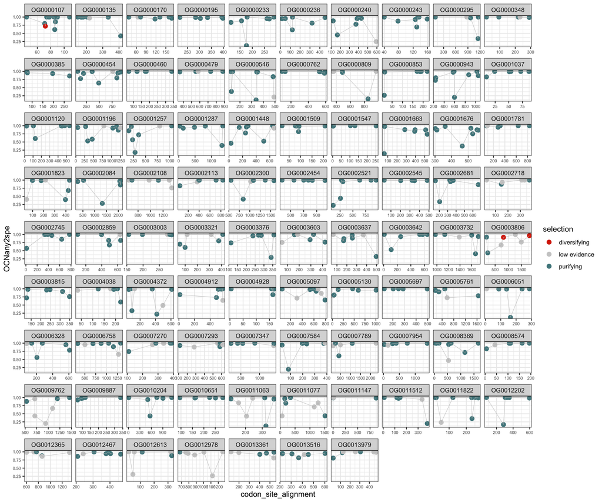

```r
individual_graphs
```

### Proportion of selective regime

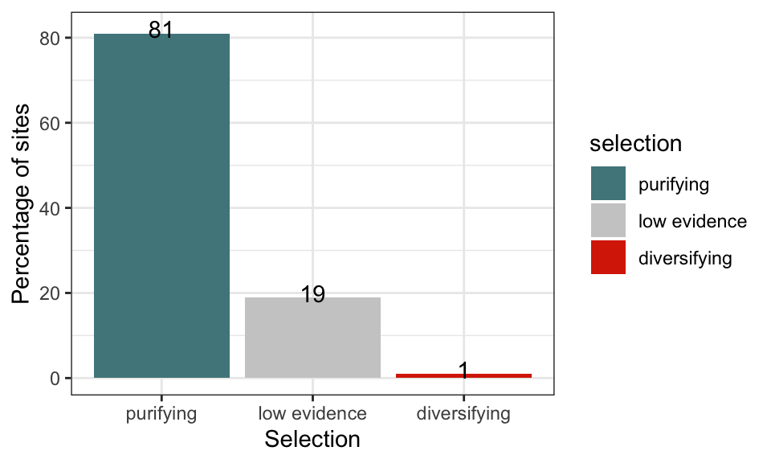

```r
site_freq
```

## Arity 7 gene.

### GALNTL6: polypeptide N-acetylgalactosaminyltransferase like 6

```r
GALNTL6_dat<-read_csv("./Datasets/DatasetS6_Non_spurious_convergence/TableS3_Orthogroup_and_arity.csv")%>% filter(arity==7)

GALNTL6_dat %>% kbl() %>%  kable_styling() %>%
  scroll_box(width = "950px", height = "400px")
```

| Orthogroup | arity | Species | Protein_id | Order | Family | Gene.name | Gene.description |
| --- | --- | --- | --- | --- | --- | --- | --- |
| OG0001663 | 7 | Amphiprion_ocellaris | XP_54873016 | Ovalentaria | Pomacentridae | GALNTL6 | si:ch211-15e22.3 [Source:ZFIN;Acc:ZDB-GENE-090312-115] |
| OG0001663 | 7 | Acanthochromis_polyacanthus | XP_51793947 | Ovalentaria | Pomacentridae | GALNTL6 | si:ch211-15e22.3 [Source:ZFIN;Acc:ZDB-GENE-090312-115] |
| OG0001663 | 7 | Salarias_fasciatus | XP_29956907 | Blenniiformes | Blenniidae | GALNTL6 | si:ch211-15e22.3 [Source:ZFIN;Acc:ZDB-GENE-090312-115] |
| OG0001663 | 7 | Echeneis_naucrates | XP_29375408 | Carangiformes | Echeneidae | GALNTL6 | si:ch211-15e22.3 [Source:ZFIN;Acc:ZDB-GENE-090312-115] |
| OG0001663 | 7 | Sphaeramia_orbicularis | XP_30009643 | Kurtiformes | Apogonidae | GALNTL6 | si:ch211-15e22.3 [Source:ZFIN;Acc:ZDB-GENE-090312-115] |
| OG0001663 | 7 | Periophthalmus_magnuspinnatus | XP_55082611 | Gobiiformes | Oxudercidae | GALNTL6 | si:ch211-15e22.3 [Source:ZFIN;Acc:ZDB-GENE-090312-115] |
| OG0001663 | 7 | Hippocampus_zosterae | XP_51902860 | Syngnathiformes | Syngnathidae | GALNTL6 | si:ch211-15e22.3 [Source:ZFIN;Acc:ZDB-GENE-090312-115] |
| OG0001663 | 7 | Hippocampus_zosterae | XP_51902150 | Syngnathiformes | Syngnathidae | GALNTL6 | si:ch211-15e22.3 [Source:ZFIN;Acc:ZDB-GENE-090312-115] |
| OG0001663 | 7 | Syngnathus_acus | XP_37125112 | Syngnathiformes | Syngnathidae | GALNTL6 | si:ch211-15e22.3 [Source:ZFIN;Acc:ZDB-GENE-090312-115] |
| OG0001663 | 7 | Corythoichthys_intestinalis | XP_57676214 | Syngnathiformes | Syngnathidae | GALNTL6 | si:ch211-15e22.3 [Source:ZFIN;Acc:ZDB-GENE-090312-115] |
| OG0001663 | 7 | Dunckerocampus_dactyliophorus | XP_54611659 | Syngnathiformes | Syngnathidae | GALNTL6 | si:ch211-15e22.3 [Source:ZFIN;Acc:ZDB-GENE-090312-115] |
| OG0001663 | 7 | Doryrhamphus_excisus | XP_57942490 | Syngnathiformes | Syngnathidae | GALNTL6 | si:ch211-15e22.3 [Source:ZFIN;Acc:ZDB-GENE-090312-115] |
| OG0001663 | 7 | Synchiropus_splendidus | XP_53703524 | Callionymiformes | Callionymidae | GALNTL6 | si:ch211-15e22.3 [Source:ZFIN;Acc:ZDB-GENE-090312-115] |

### Expression of GALNTL6 in Bgee

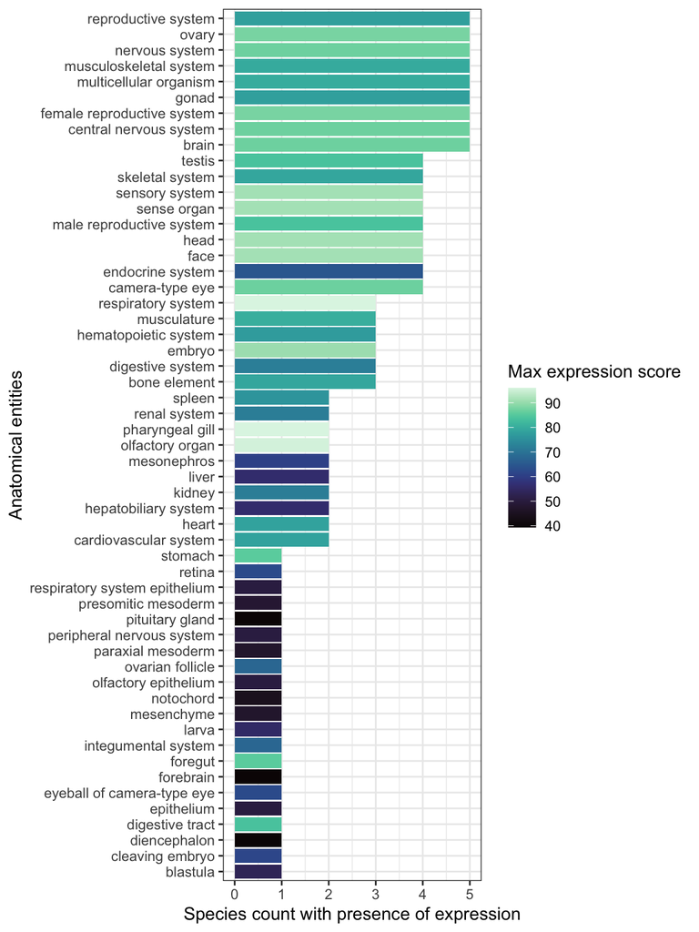

```r
bgee_comp_exp<-read_tsv("./Datasets/DatasetS15_Bgee_jsons/Bgee-expression-comparison.tsv")
bgee_comp_exp %>% filter(`Species count with presence of expression`>0) %>%
  mutate(`Anatomical entities`=reorder(`Anatomical entities`,`Species count with presence of expression`)) %>%
  ggplot(aes(y=`Anatomical entities`, x=`Species count with presence of expression`, fill=`Max expression score`))+
  geom_col()+
  viridis::scale_fill_viridis(option = "G", direction = 1)+
  theme_bw()
```